# OutFLANK Vignette

## Data checks: Heterozygosity vs. FST

Here, you can see how some of the low H loci have high FST. These are all neutral loci in the simulation, and it is important to exclude them from the OutFLANK algorithm.

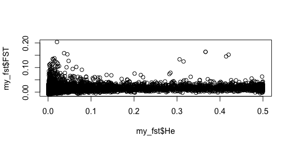

```r
plot(my_fst$He, my_fst$FST)
```

## Data checks: FST vs. FSTNoCorr

To fit the FST distribution to chi-square, OutFLANK requires the FST uncorrected for sample size (`FSTNoCorr`). This is a valid approach as long as all loci have equal sample sizes within populations. The effect of correcting for sample size will make the corrected FST estimate (`FST`) lower than the uncorrected FST estimate (`FSTNoCorr`). Note that all loci deviate between `FST` and `FSTNoCorr`, but OutFLANK assumes that these deviations are the same for each locus. If a locus has a much lower sample size compared to the rest, it could have a broader error distribution (and therefore incorrectly inferred as an outlier).

Look for loci that deviate from the linear relationship in this plot, and remove those loci.

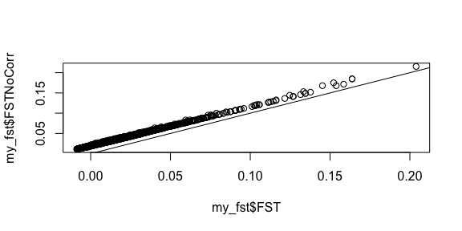

```r
plot(my_fst$FST, my_fst$FSTNoCorr)
abline(0,1)
```

Note how uncorrected FST is always larger than corrected FST. In this plot, no loci deviate from the linear relationship (because they were all genotyped in the same number of individuals).

## Data prep: decide which SNPs to use for calibrating the null distribution of Fst

Another good practice is to use a set of SNPs from the genome that are random and quasi-independent to calculate mean FST (`FSTbar`) and the degrees of freedom on the chi-square distribution (`df`). We use the term “quasi-independent” because SNPs located within the same genome can never be truly independent due to shared evolutionary history, but we mean a set of SNPs that are not in linkage disequilbrium due to physical linkage in the genome. We have found (with real and simulated whole-genome data) that non-independent representation of loci (such as from regions in which many loci display the same signal, such as in regions of low recombination or in regions of extensive sweep signals) can cause the FST distribution to no longer follow the chi-squared expectation.

Before running the OutFLANK() function to estimate the parameters on the neutral FST distribution, you will want to identify a quasi-independent set of SNPs to calculate `FSTbar` and `df`. A common way of obtaining these SNPs is to thin for linkage disequilibrium (SNP thinning), which typically moves along a genome in a sliding window and thins SNPs based on linkage disequilibrium with each other. This may be based on a combination of (i) “pruning,” which sequentially scans the genome and performs pairwise thinning based on a given threshold of correlation, (ii) “clumping,” which may incorporate some information about the importance of SNPs based on summary statistics, and (iii) removing SNPs in long-range LD regions (Prive et al. 2017).

For this vignette, we used the package `bigsnpr` to implement the three types of SNP thinning described above. The indexes of this quasi-independent set of SNPs is provided with the OutFLANK package for this vignette. For information on the code we used to obtain these SNPs and more information on SNP trimming, see the “Bonus” section at the end of the vignette.

```r
data("which_pruned")
head(which_pruned)
```

```
## [1] 1 2 3 5 8 9
```

Note how our thinned SNP set is a couple thousand SNPs fewer than our full dataset. Below, we will illustrate how to use a subset of quasi-independent SNPs to estimate `FSTbar` and `df`, and then how to use these estimates to calculate $P$-values for a much larger set of SNPs.

## OutFLANK analysis with quasi-independent set of SNPs

Next, you can run the `OutFLANK()` function to estimate the parameters on the neutral FST distribution.

```r
#### Evaluating OutFLANK with trimmed SNPs ####
out_trim <- OutFLANK(my_fst[which_pruned,], NumberOfSamples=39, qthreshold = 0.05, Hmin = 0.1)
str(out_trim)
```

```
## List of 6
##  $ FSTbar               : num 0.0175
##  $ FSTNoCorrbar         : num 0.0365
##  $ dfInferred           : num 36
##  $ numberLowFstOutliers : int 0
##  $ numberHighFstOutliers: int 7
##  $ results              :'data.frame':   3352 obs. of  15 variables:
##   ..$ LocusName       : int [1:3352] 21 109 133 290 400 424 513 515 528 687 ...
##   ..$ He              : num [1:3352] 0.032455 0.000999 0.001998 0.031488 0.1128 ...
##   ..$ FST             : num [1:3352] 0.01132 -0.00641 0.00774 0.0102 0.00156 ...
##   ..$ T1              : num [1:3352] 1.84e-04 -3.21e-06 7.74e-06 1.61e-04 8.79e-05 ...
##   ..$ T2              : num [1:3352] 0.0162 0.0005 0.001 0.0158 0.0564 ...
##   ..$ FSTNoCorr       : num [1:3352] 0.0301 0.0134 0.027 0.0291 0.0219 ...
##   ..$ T1NoCorr        : num [1:3352] 4.89e-04 6.70e-06 2.70e-05 4.58e-04 1.24e-03 ...
##   ..$ T2NoCorr        : num [1:3352] 0.0162 0.0005 0.001 0.0158 0.0564 ...
##   ..$ meanAlleleFreq  : num [1:3352] 0.984 1 0.999 0.984 0.94 ...
##   ..$ indexOrder      : int [1:3352] 1 2 3 4 5 6 7 8 9 10 ...
##   ..$ GoodH           : Factor w/ 2 levels "goodH","lowH": 2 2 2 2 1 2 2 1 1 2 ...
##   ..$ qvalues         : num [1:3352] NA NA NA NA 0.989 ...
##   ..$ pvalues         : num [1:3352] NA NA NA NA 0.056 ...
##   ..$ pvaluesRightTail: num [1:3352] NA NA NA NA 0.972 ...
##   ..$ OutlierFlag     : logi [1:3352] FALSE FALSE FALSE FALSE FALSE FALSE ...
```

```r
head(out_trim$results)
```

```
##   LocusName        He          FST            T1           T2  FSTNoCorr
## 1        21 0.0324555  0.011320095  1.838491e-04 0.0162409509 0.03013683
## 2       109 0.0009995 -0.006412466 -3.205650e-06 0.0004999091 0.01340827
## 3       133 0.0019980  0.007739770  7.737595e-06 0.0009997190 0.02700356
## 5       290 0.0314880  0.010204201  1.607806e-04 0.0157563125 0.02907417
## 8       400 0.1128000  0.001557491  8.789219e-05 0.0564319226 0.02191264
## 9       424 0.0178380  0.011030057  9.845668e-05 0.0089262163 0.03000856
##       T1NoCorr     T2NoCorr meanAlleleFreq indexOrder GoodH   qvalues
## 1 4.894857e-04 0.0162421105         0.9835          1  lowH        NA
## 2 6.703422e-06 0.0004999467         0.9995          2  lowH        NA
## 3 2.699795e-05 0.0009997921         0.9990          3  lowH        NA
## 5 4.581346e-04 0.0157574408         0.9840          4  lowH        NA
## 8 1.236668e-03 0.0564362814         0.9400          5 goodH 0.9892003
## 9 2.678821e-04 0.0089268591         0.9910          6  lowH        NA
##      pvalues pvaluesRightTail OutlierFlag
## 1         NA               NA       FALSE
## 2         NA               NA       FALSE
## 3         NA               NA       FALSE
## 5         NA               NA       FALSE
## 8 0.05603765        0.9719812       FALSE
## 9         NA               NA       FALSE
```

Check the fit and make sure it looks good, especially in the right tail:

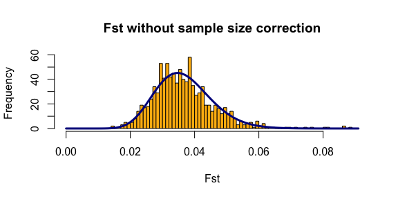

```r
OutFLANKResultsPlotter(out_trim, withOutliers = TRUE,
                       NoCorr = TRUE, Hmin = 0.1, binwidth = 0.001, Zoom =
                         FALSE, RightZoomFraction = 0.05, titletext = NULL)
```

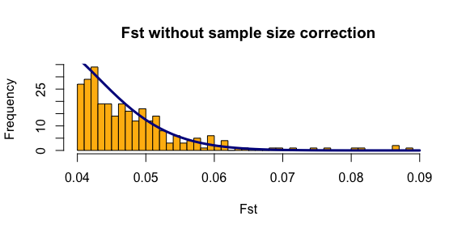

```r
## Zoom in on right tail
OutFLANKResultsPlotter(out_trim , withOutliers = TRUE,
                       NoCorr = TRUE, Hmin = 0.1, binwidth = 0.001, Zoom =
                         TRUE, RightZoomFraction = 0.15, titletext = NULL)
```

### Also check the P-value histogram:

Here, we plot the “right-tailed” P-values, which means that outliers in the right tail of the FST distribution will have a P-value near zero. Because we ran the algorithm on a trimmed set of SNPs, this will remove some of the signal around selected sites. So we expect this histogram to be flat and maybe have a bump near 0 for selected sites. This histogram looks pretty good.

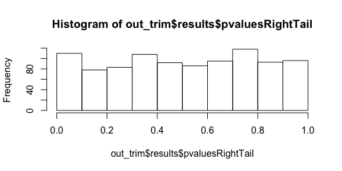

```r
hist(out_trim$results$pvaluesRightTail)
```

## Using estimated neutral mean FST and df to calculate P-values for all loci

Now that we’ve estimated neutral mean FST and df to a quasi-independent set of SNPs, we can go back and calculate P-values and q-values for all the loci in our dataset.

Note that it is important to run this code with the uncorrected FSTs (`FSTNoCorr`) and the uncorrected mean FST (`FSTNoCorrbar`).

```r
P1 <- pOutlierFinderChiSqNoCorr(my_fst, Fstbar = out_trim$FSTNoCorrbar,
                                   dfInferred = out_trim$dfInferred, qthreshold = 0.05, Hmin=0.1)
head(P1)
```

```
##    LocusName        He          FST            T1         T2  FSTNoCorr
## 7        364 0.1048395 -0.001817127 -9.529692e-05 0.05244374 0.01817915
## 8        400 0.1128000  0.001557491  8.789219e-05 0.05643192 0.02191264
## 11       515 0.3978480  0.015838733  3.153737e-03 0.19911549 0.03529322
## 12       528 0.3078000  0.012454283  1.918332e-03 0.15402989 0.03116133
## 19      1006 0.1163120  0.008938819  5.202388e-04 0.05819994 0.02822833
## 24      1191 0.1472000  0.028160513  2.075275e-03 0.07369450 0.04601685
##        T1NoCorr   T2NoCorr meanAlleleFreq    pvalues pvaluesRightTail
## 7  0.0009534549 0.05244772         0.9445 0.01031233        0.9948438
## 8  0.0012366681 0.05643628         0.9400 0.05603765        0.9719812
## 11 0.0070279450 0.19913019         0.7260 0.95337877        0.5233106
## 12 0.0048001170 0.15404083         0.8100 0.56871061        0.7156447
## 19 0.0016430073 0.05820420         0.9380 0.33627887        0.8318606
## 24 0.0033914187 0.07369950         0.9200 0.26913009        0.1345650
##      qvalues OutlierFlag
## 7  0.9758448       FALSE
## 8  0.9723056       FALSE
## 11 0.9616825       FALSE
## 12 0.9616825       FALSE
## 19 0.9616825       FALSE
## 24 0.8679210       FALSE
```

```r
tail(P1)
```

```
##      LocusName        He          FST            T1           T2
## 5935    239742 0.0009995  0.002397861  1.199012e-06 0.0005000340
## 5936    239763 0.0029955  0.006004649  8.999490e-06 0.0014987538
## 5937    239773 0.0019980  0.012070600  1.206869e-05 0.0009998418
## 5938    239841 0.0353520  0.021323859  3.773340e-04 0.0176953883
## 5939    239936 0.0019980  0.011310098  1.130807e-05 0.0009998203
## 5940    239978 0.0039920 -0.000153265 -3.060684e-07 0.0019969883
##       FSTNoCorr     T1NoCorr     T2NoCorr meanAlleleFreq pvalues
## 5935 0.02187797 1.094054e-05 0.0005000710         0.9995      NA
## 5936 0.02532571 3.795979e-05 0.0014988637         0.9985      NA
## 5937 0.03116697 3.116430e-05 0.0009999143         0.9990      NA
## 5938 0.03972360 7.029736e-04 0.0176966238         0.9820      NA
## 5939 0.03043587 3.043260e-05 0.0009998928         0.9990      NA
## 5940 0.01939605 3.873655e-05 0.0019971365         0.9980      NA
##      pvaluesRightTail qvalues OutlierFlag
## 5935               NA      NA          NA
## 5936               NA      NA          NA
## 5937               NA      NA          NA
## 5938               NA      NA          NA
## 5939               NA      NA          NA
## 5940               NA      NA          NA
```

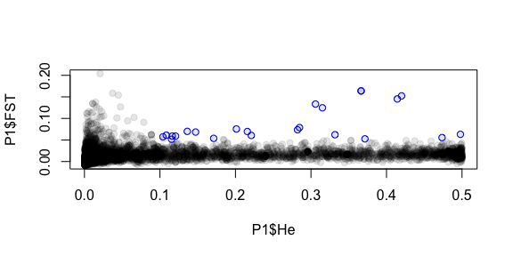

```r
# notice how the output is ordered differently

my_out <- P1$OutlierFlag==TRUE
plot(P1$He, P1$FST, pch=19, col=rgb(0,0,0,0.1))
points(P1$He[my_out], P1$FST[my_out], col="blue")
```

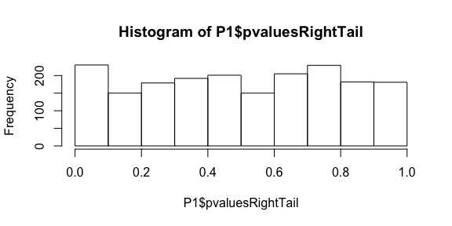

```r
hist(P1$pvaluesRightTail)
```

```r
# check the P-value histogram for the full set of data
# if there are outliers, it should look flat with an inflation near 0
```

In the P-value histogram, you can see the “bump” near 0. This occurs now because some of these loci were removed by the LD trimming.

Because of LD, we don’t really expect all the outlier loci located within a few base pairs of each other to all be causal.

## Highlight outliers on Manhattan Plot

For publication, we want to show the accurate estimate of FST, not the uncorrected estimate. Remember to exclude those low H loci!

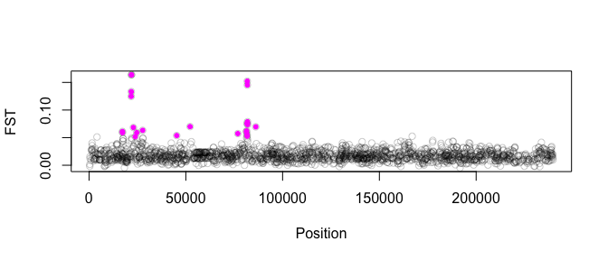

```r
plot(P1$LocusName[P1$He>0.1], P1$FST[P1$He>0.1],
     xlab="Position", ylab="FST", col=rgb(0,0,0,0.2))
  points(P1$LocusName[my_out], P1$FST[my_out], col="magenta", pch=20)
```

## Learn about the true causal loci in the simulations

The data was simulated by mutations (QTNs or quantitative trait nucleotides) that have additive effects on a phenotype, and the phenotype was under stabilizing selection with the optimum in each location dependent on the environment.

Information about the mutations that have effects on the phenotype are included with the package in the `muts` data. We can query the data for the QTNs that contribute at least 10% of the genetic variance of the phenotype:

```r
data("muts")
muts[muts$prop>0.1,]
```

```
##    position   selCoef originGen type   freq   pa2 prop count
## 7     21929 -0.338847      2119   m2 0.2415 0.021 0.21  TRUE
## 17    81730  0.531588         3   m2 0.3000 0.059 0.59  TRUE
```

Mutations at location 21929 and 81730 are discovered by OutFLANK and collectively explain 80% of the genetic variance in the trait.

## Bonus: Convert VCF to OutFLANK format

On GitHub at whilock/OutFLANK/data, you can download a vcf file of the simulations. Here is a simple script to convert a vcf file into OutFLANK format, using functions from the R package `vcfR`. Note that this code is not run with the vignette.

```
obj.vcfR <- read.vcfR("../data/sim1a.vcf.gz")

geno <- extract.gt(obj.vcfR) # Character matrix containing the genotypes
position <- getPOS(obj.vcfR) # Positions in bp
chromosome <- getCHROM(obj.vcfR) # Chromosome information

G <- matrix(NA, nrow = nrow(geno), ncol = ncol(geno))

G[geno %in% c("0/0", "0|0")] <- 0
G[geno  %in% c("0/1", "1/0", "1|0", "0|1")] <- 1
G[geno %in% c("1/1", "1|1")] <- 2

table(as.vector(G))
```

The object “G” is now in OutFLANK format.

DISCLAIMER: Note that this dataset does not include missing data, so this code may not work in all scenarios. Also, NA should be replaced with “9” to work with the functions in the OutFLANK package.

## Bonus: code used to obtain trimmed SNPs

Here is the code that we used to obtain the trimmed SNPs. Note that this code is not run with this vignette. Note also that your chromosome needs to be of class `integer` for this to work. See the `bigsnpr` package for more information on SNP trimming and how it works with this package (Prive et al. 2017). If you have difficulty loading either of these packages, please contact the developers.

Another common program used for SNP trimming is the PLINK package, and we refer users to the reference for more information (Purcell et al 2007).

```
if (!("bigstatsr" %in% installed.packages())){install.packages("bigstatsr")}
library(bigstatsr)
if (!("bigsnpr" %in% installed.packages())){devtools::install_github("privefl/bigsnpr")}
library(bigsnpr)   # package for SNP trimming

#### SNP trimming ####
G<-add_code256(big_copy(t(sim1a$G),type="raw"),code=bigsnpr:::CODE_012)
newpc<-snp_autoSVD(G=G,infos.chr =sim1a$chromosome,infos.pos = sim1a$position)
which_pruned <- attr(newpc, which="subset") # Indexes of remaining SNPS after pruning
length(which_pruned)
```

## Issues

Please post issues on GitHub. Before you contact us, please check:

- Missing data is in the correct format
- Your vectors of loci names and population names match the size of the SNP data matrix
- You have removed uniformative loci (fixed for one allele or all individuals are heterozygotes) from the data
- You’ve read all the documentation carefully and gone through the steps of this vignette

When you contact us, please:

- tell us that you have done the above four checks of your data
- give us the data and the code needed to reproduce your error

Note that not all datasets may have FST outliers. Failure to find outliers could mean that the OutFLANK algorithm is conservative for your data, but it could also mean that none of the loci in your datasets are FST outliers (e.g. are not affected by selection or some other neutral process that would make them deviate significantly from the genome-wide background).

## References

Privé F, Aschard H, Blum MGB. 2017 Efficient management and analysis of large-scale genome-wide data with two R packages: bigstatsr and bigsnpr. Bioarxiv, doi: http://dx.doi.org/10.1101/190926

Purcell S, Neale B, Todd-Brown K, et al. 2007. PLINK: A Tool Set for Whole-Genome Association and Population-Based Linkage Analyses. The American Journal of Human Genetics 81:559-575. https://doi.org/10.1086/519795

Whitlock MC and Lotterhos KE. 2015. Reliable Detection of Loci Responsible for Local Adaptation: Inference of a Null Model through Trimming the Distribution of FST. American Naturalist. 186, no. S1: S24-S36.

[session information not shown]